# 第四章 多个样本均数比较的方差分析

xianxiongma

2020年1月10日

## 知识清单

- 完全随机设计的方差分析(Completely Randomized Design)
- 随机区组设计的方差分析(Randomized block design)
- 多个样本均值间的多重比较

## 课外

- 拉丁方设计资料的方差分析
- 两阶段交叉设计的方差分析
- 多样本方差比较的Bartlett检验和Levene检验

> 主要是aov函数的使用，可以直接对aov的结果直接plot

## 1. 完全随机设计的方差分析（completely random design）

***前提：来自正态分布的独立样本；各样本方差相等**

测试数据：例04-02.sav

```
> # install.packages("memisc")
> library(memisc)
> group_df <- data.frame(as.data.set(spss.system.file('/mnt/e/医学统计学（第4版）/各章例题SPSS数据文件/例04-02.sav')))

> head(group_df)
    group ldl_c
1 placebo  3.53
2 placebo  4.59
3 placebo  4.34
4 placebo  2.66
5 placebo  3.59
6 placebo  3.13

> with(group_df, summary(aov(ldl_c ~group)))
             Df Sum Sq Mean Sq F value   Pr(>F)
group         3  32.16  10.719   24.88 1.67e-12 ***
Residuals   116  49.97   0.431
---
Signif. codes:  0 ‘***’ 0.001 ‘**’ 0.01 ‘*’ 0.05 ‘.’ 0.1 ‘ ’ 1
```

参考：  
http://www.r-tutor.com/elementary-statistics/analysis-variance/completely-randomized-design

### 2. 随机区组设计的方差分析（randomized block design）

测试数据：例04-04.sav

```
> group_df <- data.frame(as.data.set(spss.system.file('E:/医学统计学（第4版）/各章例题SPSS数据文件/例04-04.sav')))
> head(group_df)
  group treat weight
1     1   A药   0.82
2     2   A药   0.73
3     3   A药   0.43
4     4   A药   0.41
5     5   A药   0.68
6     1   B药   0.65

> with(group_df, summary(aov(weight ~ factor(treat)+factor(group))))
              Df Sum Sq Mean Sq F value  Pr(>F)
factor(treat)  2 0.2280 0.11400  11.937 0.00397 **
factor(group)  4 0.2284 0.05709   5.978 0.01579 *
Residuals      8 0.0764 0.00955
---
Signif. codes:  0 ‘***’ 0.001 ‘**’ 0.01 ‘*’ 0.05 ‘.’ 0.1 ‘ ’ 1
```

### 3. 多个样本均值间的多重比较

若用两样本均数比较的t检验进行多重比较，将会加大犯Ⅰ类错误（把本无差别的两个总体均数判为有差别）的概率。

当方差分析的结果为拒绝H0，接受H1时，说明g个总体均数不全相等。

若想进一步了解哪些两个总体均数不等，需进行多个样本均数间的两两比较或称多重比较。

#### 3.1 LSD-t检验 (least significant difference, LSD)

查表为t分布表，使用条件：**一对或几对比较**

检验统计量：

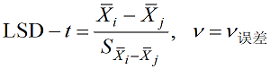

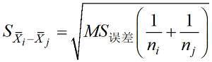

> LSD-t检验公式与两样本均数比较的t检验公式区别在于检验统计量和自由度ν的计算上。

示例数据：例04-02.sav

- 方法1：

```
> group_df <- data.frame(as.data.set(spss.system.file('E:/医学统计学（第4版）/各章例题SPSS数据文件/例04-02.sav')))
> r_mean_sq <- summary(aov(group_df$ldl_c ~ factor(group_df$group)))[[1]][-1, 3]
> v_lsd <- summary(aov(group_df$ldl_c ~ factor(group_df$group)))[[1]][-1, 1]
> ns <- table(group_df$group)
> S_lsd <- sqrt(r_mean_sq*(1/ns[c("2.4g")]+1/ns[c("placebo")]))
> delta_x <- mean(group_df$ldl_c[group_df$group=="placebo"])-mean(group_df$ldl_c[group_df$group=="2.4g"])
> pt(abs(delta_x/S_lsd), df=v_lsd, lower.tail=F)*2
        2.4g
4.887216e-05
```

- 方法2：

```
> library(agricolae)
> lsd_result <- LSD.test(aov(group_df$ldl_c ~ (group_df$group)), "group_df$group", group=T, alpha=0.01)
> lsd_result # 分组为相同说明无显著差异，如2.4g与4.8g
$statistics
    MSerror  Df   Mean      CV  t.value       LSD
  0.4307502 116 2.7025 24.2855 2.618878 0.4437949

$parameters
        test p.ajusted         name.t ntr alpha
  Fisher-LSD      none group_df$group   4  0.01

$means
        group_df$ldl_c       std  r      LCL      UCL  Min  Max    Q25   Q50    Q75
2.4g          2.715333 0.6381586 30 2.401523 3.029144 1.56 4.32 2.3175 2.665 2.9650
4.8g          2.698000 0.4971671 30 2.384190 3.011810 1.68 3.68 2.3375 2.655 2.9800
7.2g          1.966333 0.7464421 30 1.652523 2.280144 0.89 3.71 1.3350 1.905 2.4225
placebo       3.430333 0.7151247 30 3.116523 3.744144 1.37 4.59 2.9650 3.530 3.9825

$comparison
NULL

$groups
        group_df$ldl_c groups
placebo       3.430333      a
2.4g          2.715333      b
4.8g          2.698000      b
7.2g          1.966333      c

attr(,"class")
[1] "group"
```

- 方法3：

```
> pairwise.t.test(group_df$ldl_c, group_df$group)

    Pairwise comparisons using t tests with pooled SD

data:  group_df$ldl_c and group_df$group

     placebo 2.4g    4.8g
2.4g 0.00013 -       -
4.8g 0.00013 0.91871 -
7.2g 2.1e-13 0.00011 0.00013

P value adjustment method: holm
```

参考：  
https://stackoverflow.com/questions/11454521/r-t-test-and-pairwise-t-test-give-different-results

#### 3.2 Dunnett-t检验

适用条件：g-1个实验组与一个**对照组**均数差别的多重比较，检验统计量Dunnett-t 有专门的界值表，是LSD-t的特殊化

```
> library(multcomp)


> cht <- glht(aov(ldl_c ~ group, data=group_df), linfct = mcp(group= "Tukey"))
> summary(cht, test = univariate())

     Simultaneous Tests for General Linear Hypotheses

Multiple Comparisons of Means: Tukey Contrasts


Fit: aov(formula = ldl_c ~ group, data = group_df)

Linear Hypotheses:
                    Estimate Std. Error t value Pr(>|t|)
2.4g - placebo == 0 -0.71500    0.16946  -4.219 4.89e-05 ***
4.8g - placebo == 0 -0.73233    0.16946  -4.322 3.29e-05 ***
7.2g - placebo == 0 -1.46400    0.16946  -8.639 3.57e-14 ***
4.8g - 2.4g == 0    -0.01733    0.16946  -0.102    0.919
7.2g - 2.4g == 0    -0.74900    0.16946  -4.420 2.23e-05 ***
7.2g - 4.8g == 0    -0.73167    0.16946  -4.318 3.34e-05 ***
---
Signif. codes:  0 ‘***’ 0.001 ‘**’ 0.01 ‘*’ 0.05 ‘.’ 0.1 ‘ ’ 1
(Univariate p values reported)

> cht <- glht(aov(ldl_c ~ group, data=group_df), linfct = mcp(group= "Dunnett"), alternative="two.sided")
> summary(cht)

     Simultaneous Tests for General Linear Hypotheses

Multiple Comparisons of Means: Dunnett Contrasts


Fit: aov(formula = ldl_c ~ group, data = group_df)

Linear Hypotheses:
                    Estimate Std. Error t value Pr(>|t|)
2.4g - placebo == 0  -0.7150     0.1695  -4.219 0.000131 ***
4.8g - placebo == 0  -0.7323     0.1695  -4.322  < 1e-04 ***
7.2g - placebo == 0  -1.4640     0.1695  -8.639  < 1e-04 ***
---
Signif. codes:  0 ‘***’ 0.001 ‘**’ 0.01 ‘*’ 0.05 ‘.’ 0.1 ‘ ’ 1
(Adjusted p values reported -- single-step method)
```

#### 3.3 SNK-q检验

适用条件：多个样本均数两两之间的**全面比较**（比较所有的组）

```
> # 新用法
> agricolae::SNK.test(aov(ldl_c ~ group, data=group_df), "group",  console = T)

Study: aov(ldl_c ~ group, data = group_df) ~ "group"

Student Newman Keuls Test
for ldl_c

Mean Square Error:  0.4307502

group,  means

           ldl_c       std  r  Min  Max
2.4g    2.715333 0.6381586 30 1.56 4.32
4.8g    2.698000 0.4971671 30 1.68 3.68
7.2g    1.966333 0.7464421 30 0.89 3.71
placebo 3.430333 0.7151247 30 1.37 4.59

Alpha: 0.05 ; DF Error: 116

Critical Range
        2         3         4
0.3356368 0.4023275 0.4417253

Means with the same letter are not significantly different.

           ldl_c groups
placebo 3.430333      a
2.4g    2.715333      b
4.8g    2.698000      b
7.2g    1.966333      c
> print(agricolae::SNK.test(aov(ldl_c ~ group, data=group_df), "group", alpha=0.01))
$statistics
    MSerror  Df   Mean      CV
  0.4307502 116 2.7025 24.2855

$parameters
  test name.t ntr alpha
   SNK  group   4  0.01

```

[output cut: 13 more lines]

```
$comparison
NULL

$groups
           ldl_c groups
placebo 3.430333      a
2.4g    2.715333      b
4.8g    2.698000      b
7.2g    1.966333      c

attr(,"class")
[1] "group"

# 旧用法
SNK.test(y, treat, DFerror, MSerror)
```

### 4. 拉丁方设计资料的方差分析

- 数据准备

```
> library("memisc")
> group_df <- data.frame(as.data.set(spss.system.file('E:/医学统计学（第4版）/各章例题SPSS数据文件/例04-05_1.sav')))
> head(group_df)
  row column treat result
1   1      1     C     87
2   1      2     B     75
3   1      3     E     81
4   1      4     D     75
5   1      5     A     84
6   1      6     F     66
```

- 方差分析

```
> group_df$row <- factor(group_df$row)
> group_df$col <- factor(group_df$column)
> model<- aov(result~row + col + treat, data=group_df)
> summary(model)
            Df Sum Sq Mean Sq F value Pr(>F)
row          5  250.5   50.09   1.424 0.2584
col          5   75.1   15.03   0.427 0.8242
treat        5  657.3  131.47   3.738 0.0149 *
Residuals   20  703.4   35.17
---
Signif. codes:  0 ‘***’ 0.001 ‘**’ 0.01 ‘*’ 0.05 ‘.’ 0.1 ‘ ’ 1
```

### 5. 两阶段交叉设计的方差分析

即按个体分解，按阶段分解和按处理分解进行方差分析，代码与拉丁方的方法大致相同

### 6. Bartlett检验（需要正态整体）

```
> library("memisc")
> group_df <- data.frame(as.data.set(spss.system.file('E:/医学统计学（第4版）/各章例题SPSS数据文件/例04-02.sav')))
> head(group_df)
    group ldl_c
1 placebo  3.53
2 placebo  4.59
3 placebo  4.34
4 placebo  2.66
5 placebo  3.59
6 placebo  3.13
> bartlett.test(ldl_c~group, data=group_df) # bartlett.test(group_df$ldl_c,group_df$group)

    Bartlett test of homogeneity of variances

data:  ldl_c by group
Bartlett's K-squared = 5.2192, df = 3, p-value = 0.1564
```

参考：  
https://stat.ethz.ch/R-manual/R-devel/library/stats/html/bartlett.test.html

### 7. Levene检验（不必要正态整体）【还有一个Fligner-Killeen test，见参考】

```
> library(car)


> leveneTest(ldl_c~group, data=group_df)
Levene's Test for Homogeneity of Variance (center = median)
       Df F value Pr(>F)
group   3   1.493 0.2201
      116
```

参考：  
http://blog.sina.com.cn/s/blog_5cd2f1e20101979p.html  
http://www.cookbook-r.com/Statistical_analysis/Homogeneity_of_variance/